# Cox 迴歸分析 (Cox Regression)

JianKai Wang (https://sophia.ddns.net/)

2018年4月8日

在進行存活分析時，可以透過 Log-rank test 來比較組別之間的存活曲線是否有顯著差異。但當`自變項是連續變項`或`自變項超過2個以上`時的分析時，就需要透過 `Cox Regression (Cox Proportional Hazard Model)` 來達成。Cox Regression Model 是使用有母數分析的預測方式，用以分析影響死亡率的變數(或影響存活率的重要因子)。在討論 cox regression 時有二個部分需要先釐清，即 **存活函式** 與 **風險函式**:

- 存活函式 (Survival Function):

目的是呈現在某特定時間點下，個案可以活過此特定時間點的機率為何。

$$S(t) = P(T > t) = \int_t^{\infty}f(u)du$$

其中 $t$ 為時間點，$S(0)=1$, $S(\infty)=0$。

- 風險函式 (Hazard Function):

$$h(t) = \frac{\frac{-d[S(t)]}{dt}}{S(t)} = \frac{f(t)}{S(t)} \\
S(t) = exp(-\int_0^th(u)du)$$

其中 $t$ 為時間點，風險函式 $h(t)$ 值與存活時間有關，此代表在某一時間點下，事件機率(死亡)除以生存函式的值。若時間越久 ($t$ 越大)，存活函式 $S(t)$ 越小 (存活函式為遞減函式)，**假設死亡機率密度 $f(t)$ 對任何時間點都一樣**，則風險函式 $h(t)$ 值越大，預期存活時間短。

**在經典的 Cox Regression 的等比例風險假設(Proportional hazard assumption, PH assumption)假設下，針對某一危險因子而言，其風險比，不能隨著時間而有所改變，必須要固定。**。

由上可之，推導 Cox Regression 可得：

$$h(t) = \lambda \\
S(t) = exp(-\int_0^th(u)du) = exp(-\lambda t) = e^{-\lambda t} \\
f(t) = h(t) * S(t) = \lambda * e^{-\lambda t}$$

而因 $\lambda$ 為一定值，故可以推出 Cox Regression 為:

$$log(HR(x))=log(\frac{h(t|x)}{h_0(t)}) = \beta_1{x_1} + \beta_2{x_2} + ... + \beta_k{x_k} + \varepsilon$$

此即為迴歸方程式。Hazard Ratio ($HR$) 表示某個時間下會發生事件的風險比，而 $HR(x)$ 表示在給定 x 下會發生事件的風險比，x 即是自變項的數值，如年齡90歲便是一個數值 x。$h(t|x)$ 表示在第 $t$ 個時間點時，給定 x 值時的風險。$h_0(t)$ 表示在第 $t$ 個時間點時的基礎風險。而 Hazard Ratio ($HR$) 計算範例為當僅有一變項 $x_1$，$x_1=1$ 表示為男性，$x_1=0$ 表示為女性，則 $exp(\beta_1)$ 為男性相對於女性的危險比率，且 $HR=\frac{exp(\beta_0 + \beta_1)}{exp(\beta_0)}$。

Cox Regression 不僅可以用來分析病因與死亡率之間的關係，更可以延伸至企業倒閉風險分析等議題上。

## 套件安裝

於 R 實作中，可以透過套件 **survival** 來實現存活分析。

```r
packageName <- c("survival")
for(i in 1:length(packageName)) {
  if(!(packageName[i] %in% rownames(installed.packages()))) {
    install.packages(packageName[i])
  }
}
lapply(packageName, require, character.only = TRUE)
```

```
## [[1]]
## [1] TRUE
```

## 使用函式介紹

| 函式名稱 | 函式用途 |
| --- | --- |
| Surv | 創造一個存活分析的物件，通常在迴歸公式中代表應變數(response variable) |
| coxph | Fit Proportional Hazards Regression Model |
| coxph.control | 控制 coxph 擬合的輔助參數 |
| cox.zph | 測試迴歸模型中的比例風險假設 |
| cox.detail | Cox 迴歸模型的細節，此函式會回傳在每個獨立時間下的 1 階, 2 階的導數矩陣 |
| strata | 用來分層分析變數 |

## 資料準備

```r
data("ovarian")
head(ovarian, 10)
```

```
##    futime fustat     age resid.ds rx ecog.ps
## 1      59      1 72.3315        2  1       1
## 2     115      1 74.4932        2  1       1
## 3     156      1 66.4658        2  1       2
## 4     421      0 53.3644        2  2       1
## 5     431      1 50.3397        2  1       1
## 6     448      0 56.4301        1  1       2
## 7     464      1 56.9370        2  2       2
## 8     475      1 59.8548        2  2       2
## 9     477      0 64.1753        2  1       1
## 10    563      1 55.1781        1  2       2
```

其中 futime 為生存或是資料不再更新(如刪除，不再追蹤)的時間，fustat 為是否有持續追蹤的指標(censoring status)，age 為年齡，resid.ds 是否目前仍有疾病 (1為無,2為有)，rx 為治療或控制組(1 為控制組 placebo, 2 為治療組 thiopeta)，ecog.ps 為美國東岸癌症臨床研究合作組織定義之日常體能狀態(1 為較佳，分數越高越差)。

## 迴歸分析

```r
# the prototype of Surv
# time 為與時間並進的變數
# event 為指標，需考慮 type 為何；預設為 0 為存活，1 為死亡
# type 為 censoring 的型態，此會與 event 之值有關
Surv(time, time2, event,
    type=c('right', 'left', 'interval', 'counting', 'interval2', 'mstate'))
```

```r
# the prototype of coxph
# formula: 需注意先將應變數透過函式(Surv)轉為物件
# init: 反覆計算中使用的初始值向量，預設皆為 0
# control: 其他用於反覆計算之參數選項，可接受 coxph.control 定義之物件
# ties: 預設為 Efron，處理死亡時間更精確
# singular.ok: 如何處理模型矩陣中的共線性
# robust: 若為真，將可得到一穩定的變異(Variance)估計
coxph(formula, data, weights, subset,
      na.action, init, control,
      ties=c("efron","breslow","exact"),
      singular.ok=TRUE, robust=FALSE,
      model=FALSE, x=FALSE, y=TRUE, tt, ...)
```

```r
# the prototype of coxph.control
coxph.control(eps = 1e-09, toler.chol = .Machine$double.eps^0.75,
      iter.max = 20, toler.inf = sqrt(eps), outer.max = 10, timefix=TRUE)
```

```r
ova.fit <- coxph(Surv(futime, fustat) ~ age + ecog.ps, data = ovarian)
ova.fit
```

```
## Call:
## coxph(formula = Surv(futime, fustat) ~ age + ecog.ps, data = ovarian)
##
##           coef exp(coef) se(coef)    z      p
## age     0.1615    1.1753   0.0499 3.24 0.0012
## ecog.ps 0.0187    1.0188   0.5991 0.03 0.9751
##
## Likelihood ratio test=14.3  on 2 df, p=0.000787
## n= 26, number of events= 12
```

Cox regression 結果中顯示，coef 為變數 age 或 ecog.ps 的係數，exp(coef) 是一個生存比率，se(coef) 為係數的標準差，而 Z 表示 Z-score，P 為 P-value，可以透過 Z-score 來推求出 P-value。

## 驗證風險假設

```r
# the prototype of cox.zph
# transform: 指定在驗證假設前將存活時間進行轉換的方法
# global: 除了單變數檢驗外，是否需要進行全域卡方檢驗
cox.zph(fit.model, transform="km", global=TRUE)
```

```r
ova.test <- cox.zph(ova.fit, transform="km", global=TRUE)
print(ova.test)
```

```
##            rho chisq     p
## age     -0.243 0.856 0.355
## ecog.ps  0.520 2.545 0.111
## GLOBAL      NA 3.195 0.202
```

## 繪迴歸曲線結果

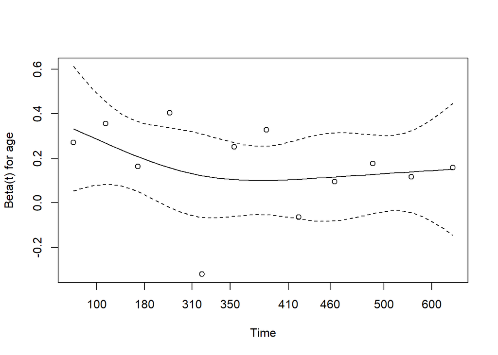

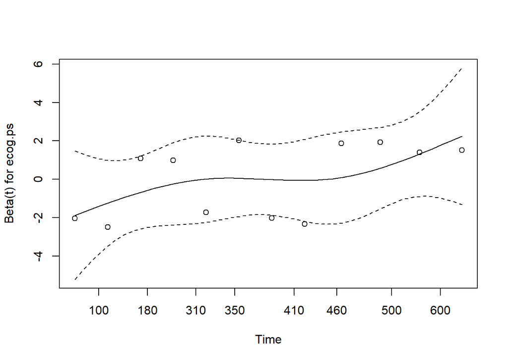

```r
plot(ova.test)
```

## 迴歸模型細節

透過 **coxph.detail** 回傳許多計算細節，將有利於導入新的方法。

```r
coxph.detail(ova.fit)
```

```
## $time
##  [1]  59 115 156 268 329 353 365 431 464 475 563 638
##
## $means
##          age  ecog.ps
## 59  69.09819 1.455425
## 115 68.46900 1.544049
## 156 66.17359 1.751348
## 268 66.13888 1.721811
## 329 59.69610 1.507553
## 353 59.77545 1.509985
## 365 59.28316 1.439937
## 431 58.40780 1.596546
## 464 58.75868 1.583439
## 475 58.91087 1.548638
## 563 56.39392 1.688778
## 638 56.53567 1.652492
##
## $nevent
##  [1] 1 1 1 1 1 1 1 1 1 1 1 1
##
## $nrisk
##  [1] 26 25 24 23 22 21 20 17 15 14 12 11
##
## $hazard
##  [1] 0.01207211 0.01442131 0.01991626 0.02228211 0.03944350 0.03963251
##  [7] 0.04529802 0.06142322 0.06738846 0.07301832 0.12124602 0.13538256
##
## $score
##             age    ecog.ps
## 59    3.2333105 -0.4554246
## 115   6.0242037 -0.5440489
## 156   0.2922075  0.2486520
## 268   8.3652187  0.2781892
## 329 -16.5590971 -0.5075530
## 353   3.4437534  0.4900149
## 365   5.1415416 -0.4399369
## 431  -8.0681010 -0.5965458
## 464  -1.8216798  0.4165610
## 475   0.9439309  0.4513619
```

[output cut: 124 more lines]

```
## 7  56.9370       2
## 8  59.8548       2
## 9  64.1753       1
## 10 55.1781       2
## 11 56.7562       2
## 12 50.1096       1
## 13 59.6301       2
## 14 57.0521       1
## 15 39.2712       1
## 16 43.1233       2
## 17 38.8932       2
## 18 44.6000       1
## 19 53.9068       1
## 20 44.2055       1
## 21 59.5890       2
```

## 分層分析

經典的存活分析建立在等比例風險假設(Proportional hazard assumption, PH assumption)。但當風險因子會隨著時間改變時，原本的 Cox 迴歸模型就需要修正，其中最常使用的便是分層 Cox 迴歸模型。分層 Cox 迴歸模型將這些不符合等比例風險假設的因子當作分層變數，表示不同層的基礎危險函式(baseline hazard function)是不同的，但需注意分層數若太多可能會降低統計檢定力(statistical power)。在 R 實作中可透過函式 **strata** 針對某一變數進行分層分析。

```r
strata.data <- data.frame(
  time = c(4,3,1,1,2,2,3),
  status = c(1,1,1,0,1,1,0),
  x = c(0,2,1,1,1,0,0),
  sex = c(0,0,0,0,1,1,1)
)
summary(coxph(Surv(time,status) ~ x + strata(sex), data=strata.data))
```

```
## Call:
## coxph(formula = Surv(time, status) ~ x + strata(sex), data = strata.data)
##
##   n= 7, number of events= 5
##
##     coef exp(coef) se(coef)     z Pr(>|z|)
## x 0.8023    2.2307   0.8224 0.976    0.329
##
##   exp(coef) exp(-coef) lower .95 upper .95
## x     2.231     0.4483    0.4451     11.18
##
## Concordance= 0.667  (se = 0.362 )
## Rsquare= 0.144   (max possible= 0.669 )
## Likelihood ratio test= 1.09  on 1 df,   p=0.2971
## Wald test            = 0.95  on 1 df,   p=0.3293
## Score (logrank) test = 1.05  on 1 df,   p=0.3053
```